# Simple Linear Regression in R

Ryan Yee

2023-04-17

```r
library(tidyverse)
```

## Dataset

We will use FiveThirtyEight’s Soccer Power Index dataset. I am taking the first 1000 observations, there are over 11,000 observations in the full dataset (this will make it easier to visualize). There are two key variables: `spi` which rates a team’s strength and `xg` which is the number of goals we would expect a team to score in a game given the shots they took.

```r
head(spi)
```

```
##    spi1  spi2  xg1  xg2
## 1 48.22 37.83 1.39 0.26
## 2 39.81 60.08 0.57 2.76
## 3 65.59 39.99 0.49 0.45
## 4 32.25 54.82 1.12 0.97
## 5 38.24 40.45 2.77 3.17
## 6 31.99 38.75 1.33 0.65
```

```r
dim(spi)
```

```
## [1] 1000    4
```

We will be interested in predicting the difference in expected goals (`xg`) based on the difference in team strength (`spi`).

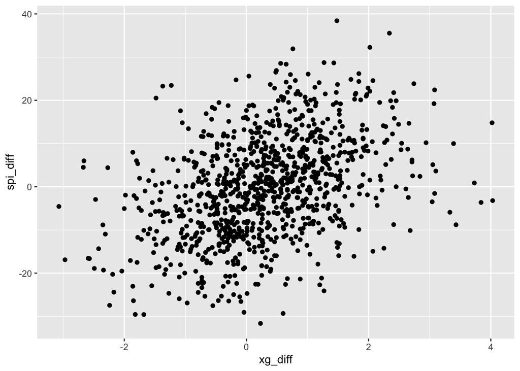

```r
spi <- spi %>%
  mutate(
    xg_diff = xg1 - xg2,
    spi_diff = spi1 - spi2
  )

spi %>%
  ggplot(aes(x = xg_diff, y = spi_diff)) +
  geom_point()
```

## SLR Model

We will fit a simiple linear regression in the following form:

$$\text{xG Difference} = \text{SPI
Difference} * \beta + \alpha$$

where $\beta$ is our slope term and $\alpha$ is our constant or intercept term. Note we are trying to predict the difference in expected goals from the difference in SPI or team strength.

```r
slr <- lm(xg_diff ~ spi_diff, data = spi)
slr
```

```
##
## Call:
## lm(formula = xg_diff ~ spi_diff, data = spi)
##
## Coefficients:
## (Intercept)     spi_diff
##     0.30909      0.03699
```

Our estimates are $\hat{\beta} = 0.03699$ and $\hat{\alpha} = 0.30909$

## Model Summary

We can view a more useful summary using the `summary` function. This is useful for the interpretation portion of the analysis.

```r
summary(slr)
```

```
##
## Call:
## lm(formula = xg_diff ~ spi_diff, data = spi)
##
## Residuals:
##     Min      1Q  Median      3Q     Max
## -3.2100 -0.6260 -0.0194  0.5941  3.8397
##
## Coefficients:
##             Estimate Std. Error t value Pr(>|t|)
## (Intercept) 0.309090   0.031149   9.923   <2e-16 ***
## spi_diff    0.036995   0.002647  13.976   <2e-16 ***
## ---
## Signif. codes:  0 '***' 0.001 '**' 0.01 '*' 0.05 '.' 0.1 ' ' 1
##
## Residual standard error: 0.985 on 998 degrees of freedom
## Multiple R-squared:  0.1637, Adjusted R-squared:  0.1629
## F-statistic: 195.3 on 1 and 998 DF,  p-value: < 2.2e-16
```

## Diagnostic Plots

We will need to look at diagnostic plots to justify the assumptions of our model are met. (This may or may not be discussed in lecture, so I will not go into details on how to assess the assumptions here).

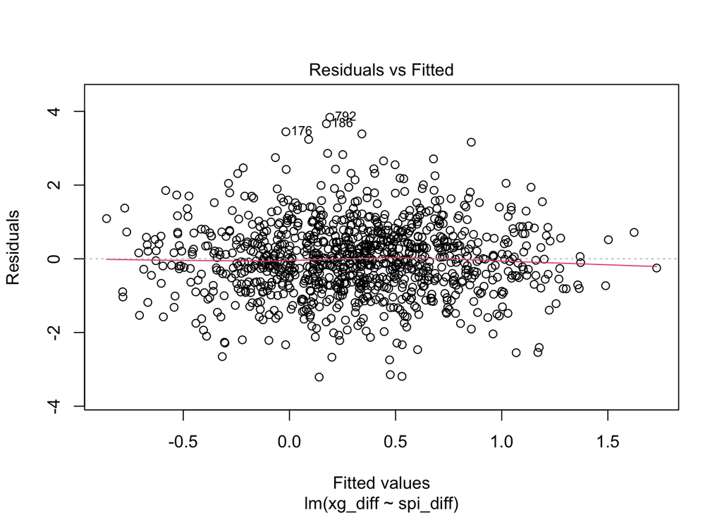

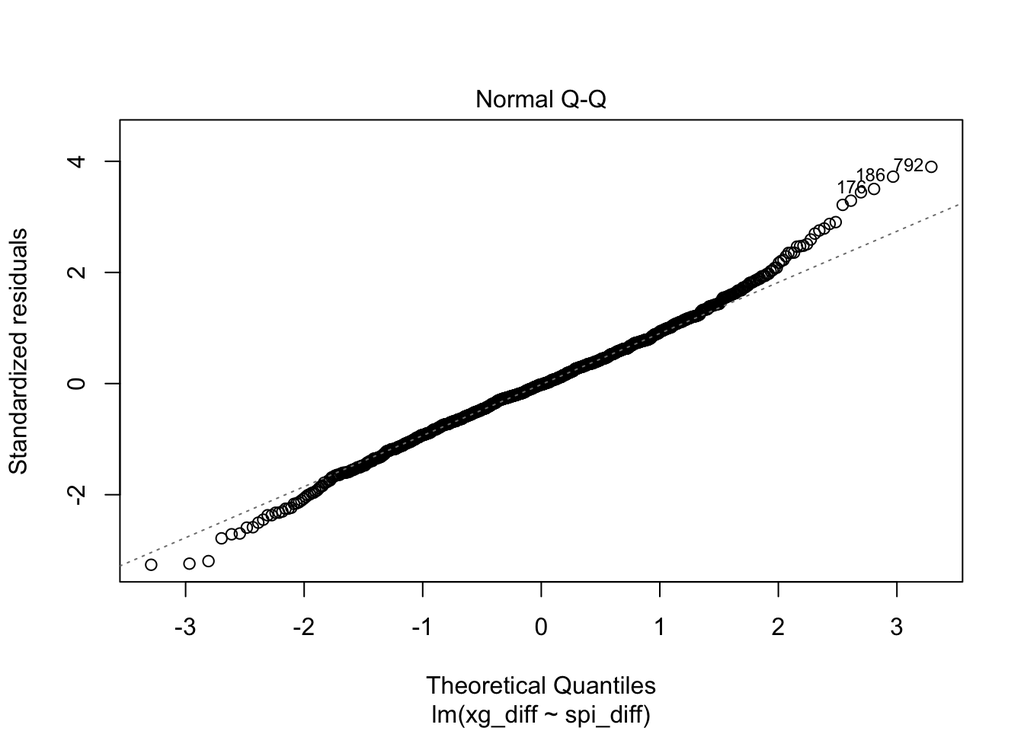

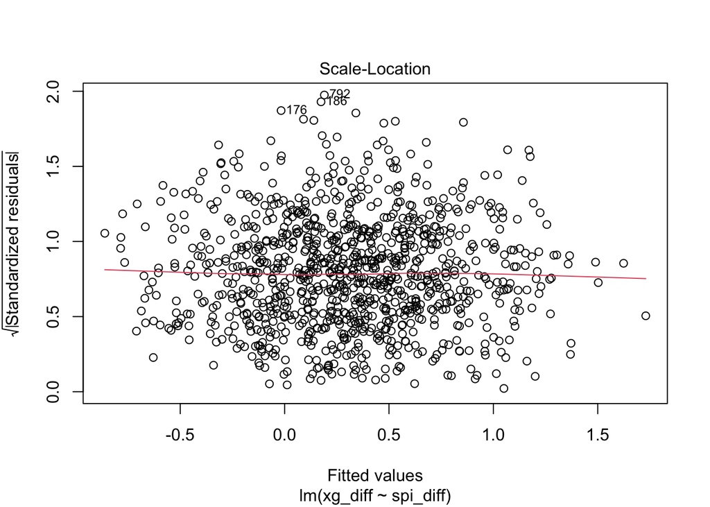

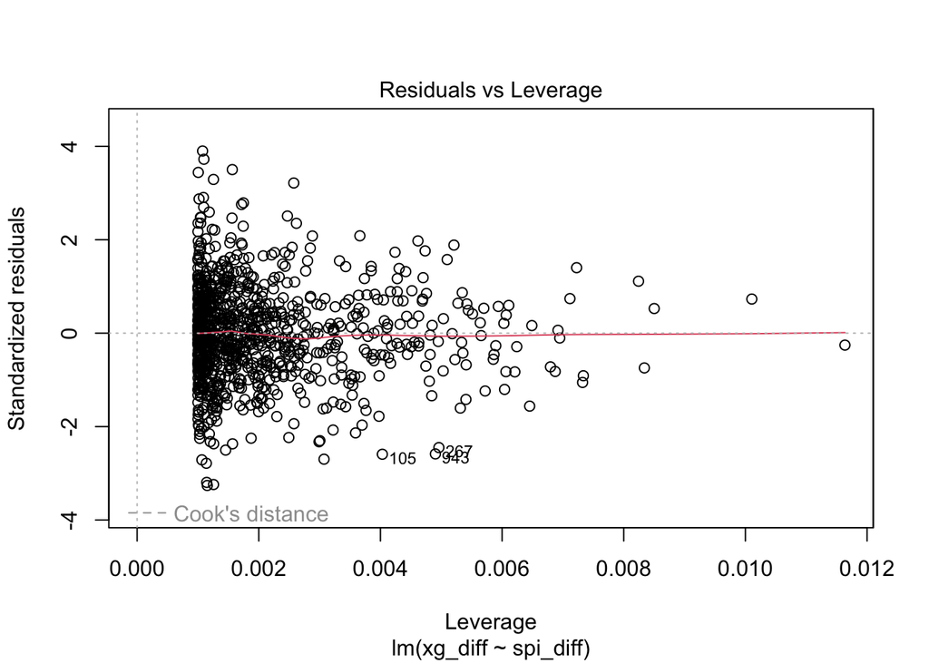

```r
plot(slr)
```

## Visualize Model

We can visualize the model using `ggplot`.

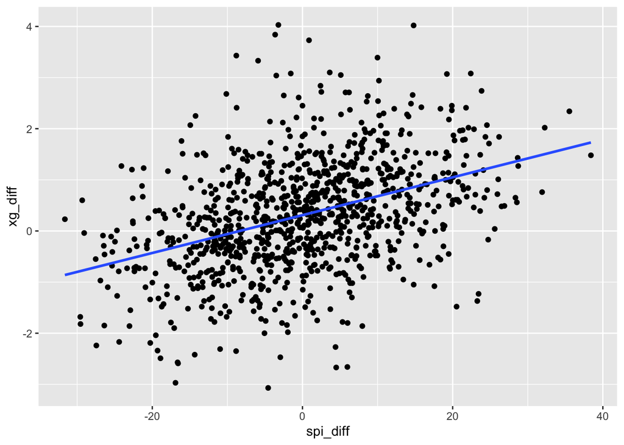

```r
ggplot(spi, aes(x = spi_diff, y = xg_diff)) +
  geom_point() +
  geom_smooth(method = "lm", se = FALSE)
```